# Session 4: Plotting

### Addying layers

To add a line plot, we use the `geom_line()` function.

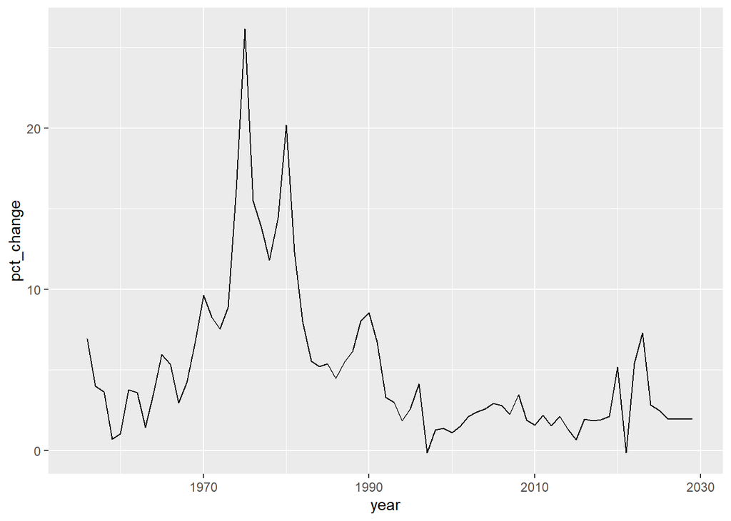

```r
# Create the plot canvas
gdp_deflators_df |>
  ggplot(aes(x = year, y = pct_change)) +
  # create a line plot
  geom_line()
```

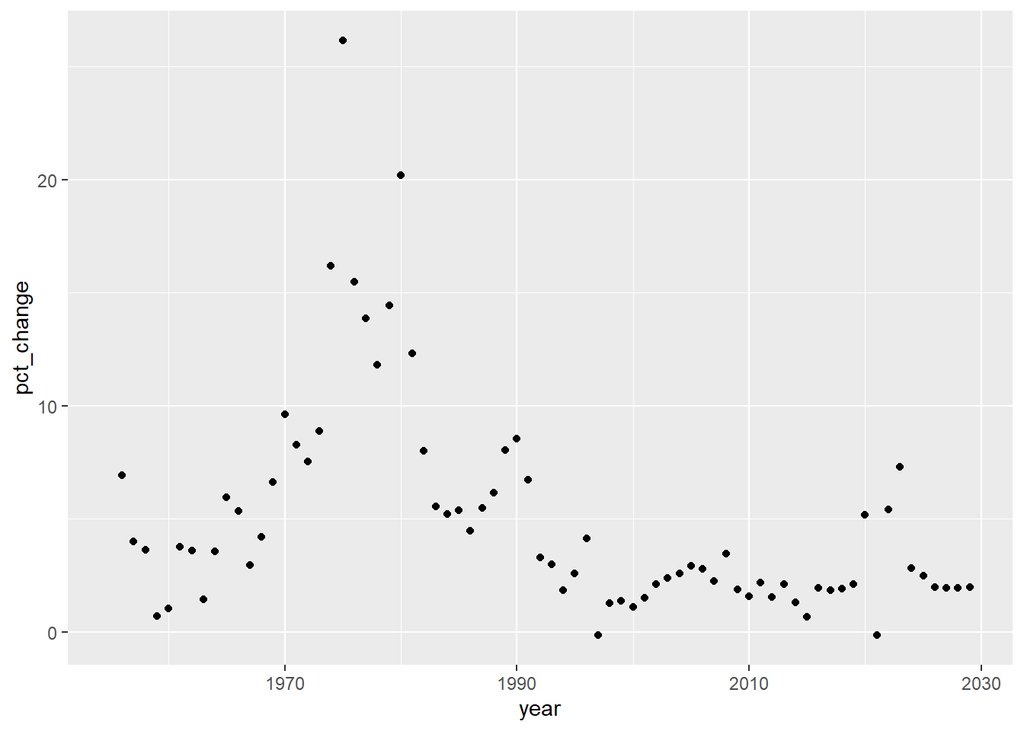

```r
gdp_deflators_df |>
  ggplot(aes(x = year, y = pct_change)) +
  # create a point plot instead
  geom_point()
```

Or we can combine two layers as so.

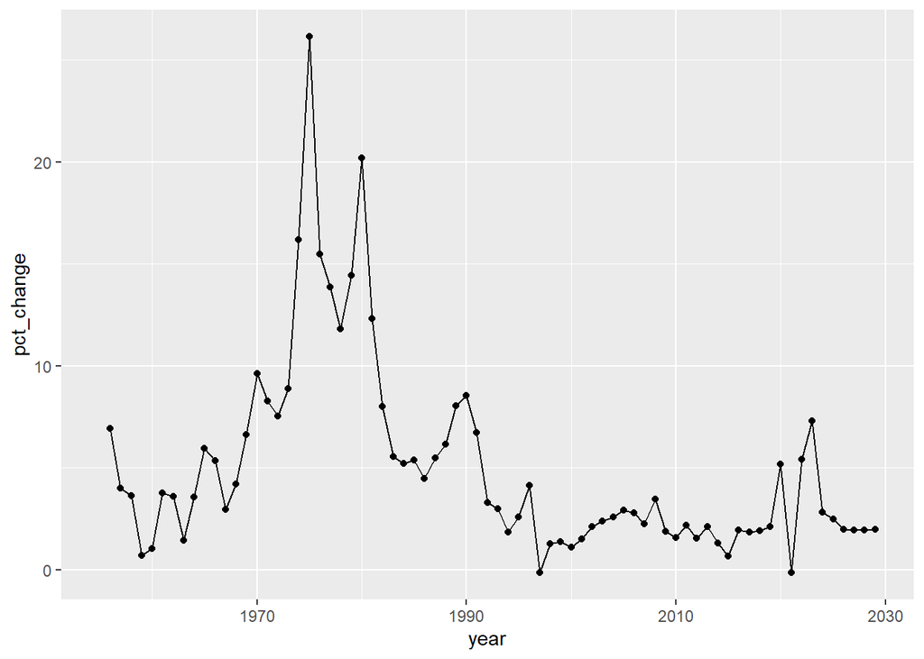

```r
gdp_deflators_df |>
  ggplot(aes(x = year, y = pct_change)) +
  # combine line and point plot together
  geom_line() +
  geom_point()
```

A bar plot can be created by the `geom_col()`

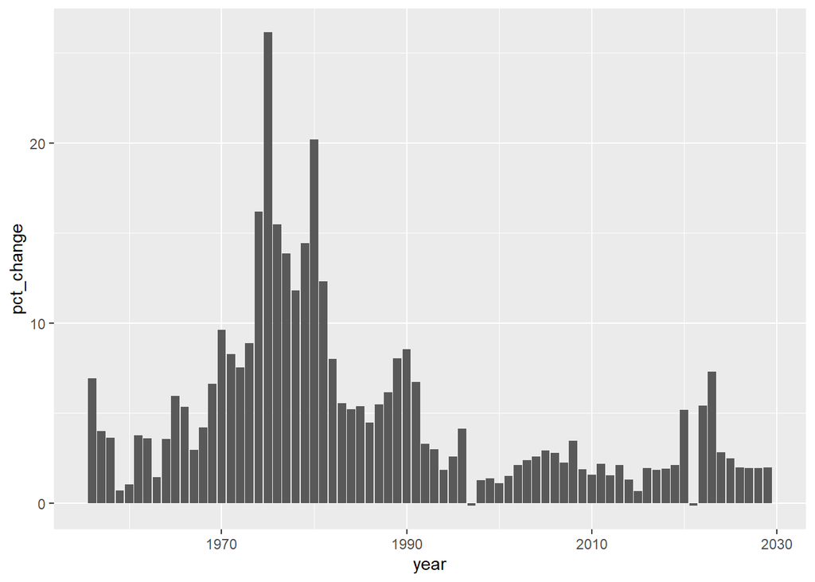

```r
gdp_deflators_df |>
  ggplot(aes(x = year, y = pct_change)) +
  # create a bar chart
  geom_col()
```

You will also see code that uses `geom_bar()` to create bar charts. The default behaviour for this geometry is to plot the number of counts of the specified `x` argument.

Apart from the mapping of a variable to an axis, we can also map variables to other aesthetics, such as fill/colour, size, linetype, alpha to convey more information about the data.

Say we want to distinguish between observed and forecast values. The values for the years beyond 2024 are forecast.

We can create a variable in the data before it is piped to `ggplot()` called `forecast` which does this. Then within the `aes()` a `fill` argument can be set as forecast.

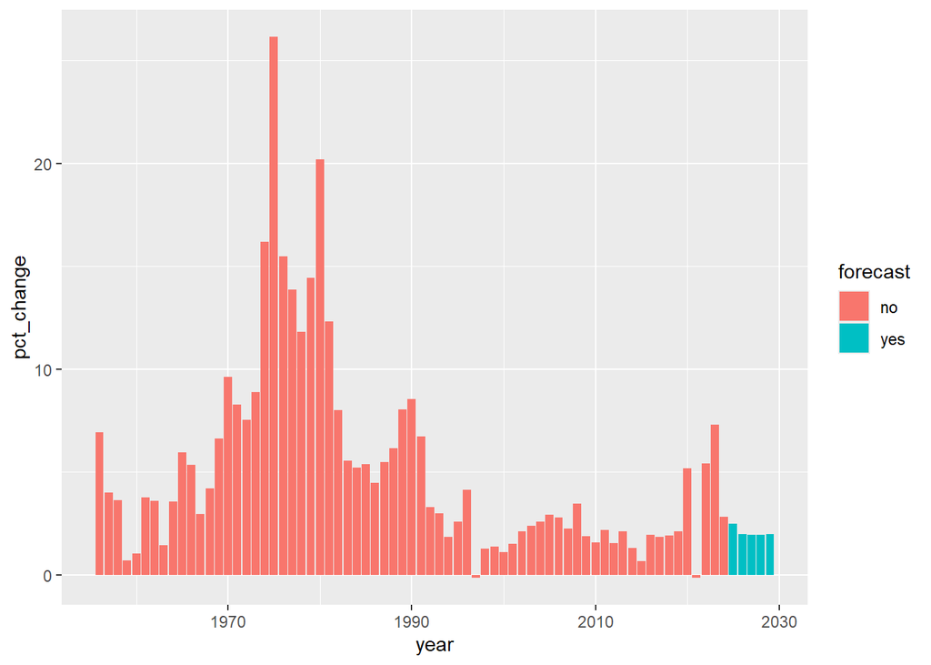

```r
gdp_deflators_df |>
  # create a variable to show if it is a forecast
  mutate(forecast = if_else(year > 2024, "yes", "no")) |>
  # apply this a mapping to distinguish between forecast and observed
  ggplot(aes(x = year, y = pct_change, fill = forecast)) +
  geom_col()
```

This calculation can be done within the `aes()` itself rather than within a `mutate()` beforehand.

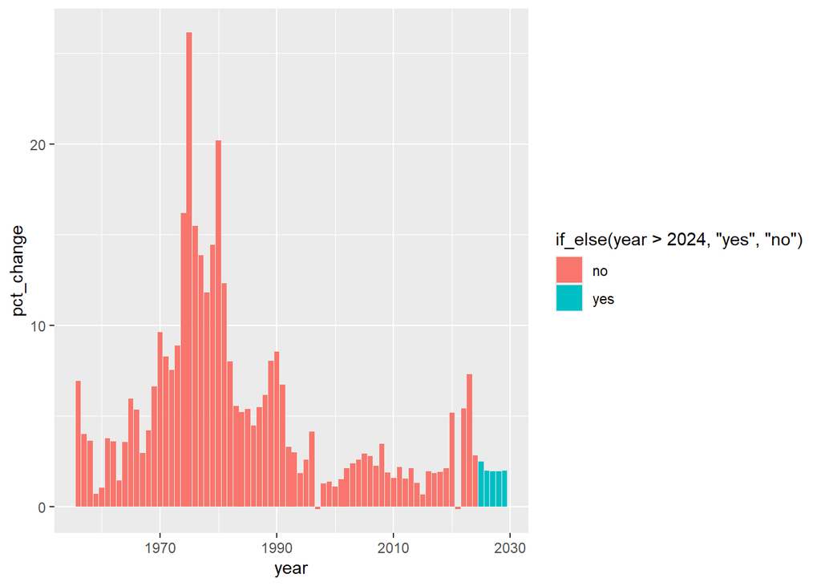

```r
gdp_deflators_df |>
  ggplot(aes(x = year, y = pct_change, fill = if_else(year > 2024, "yes", "no"))) +
  geom_col()
```

## Improving Visulations

Whilst the above creates the visualisations, there are many tweaks we need to do to make them a lot more aesthetically pleasing. This can be done by a number of ways, including labelling, and by applying a theme.

### Apply labels

There a number of ways to apply labels to a plot but the `labs()` function is the most useful as it can apply a title, subtitle, caption and change the aesthetics labels too.

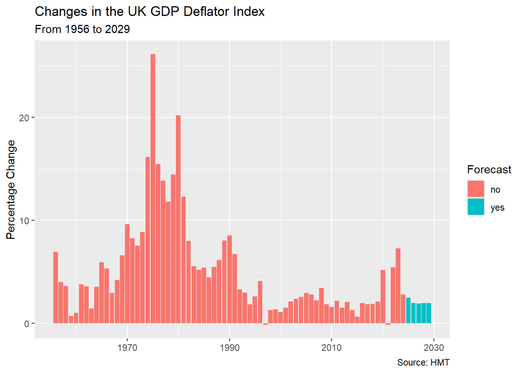

```r
gdp_deflators_df |>
  ggplot(aes(x = year, y = pct_change, fill = if_else(year > 2024, "yes", "no"))) +
  geom_col() +
  # applying lables to the plot
  labs(
    title = "Changes in the UK GDP Deflator Index",
    subtitle = "From 1956 to 2029",
    x = NULL,
    y = "Percentage Change",
    fill = "Forecast",
    caption = "Source: HMT"
  )
```

### Changing scales

The `scales_*()` set of functions are used to control the aesthetics specified in the `aes()` function.

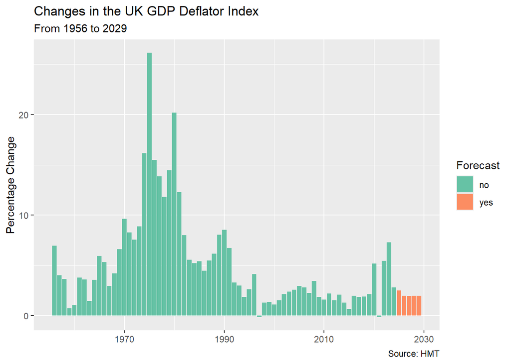

```r
gdp_deflators_df |>
  ggplot(aes(x = year, y = pct_change, fill = if_else(year > 2024, "yes", "no"))) +
  geom_col() +
  labs(
    title = "Changes in the UK GDP Deflator Index",
    subtitle = "From 1956 to 2029",
    x = NULL,
    y = "Percentage Change",
    fill = "Forecast",
    caption = "Source: HMT"
  ) +
  scale_fill_brewer(palette = "Set2")
```

### Applying a theme

To control the non-data elements of the plot, a themes can be applied. A number of basic themes are included within the `{ggplot2}` package. All these are in the form of `theme_*()`.

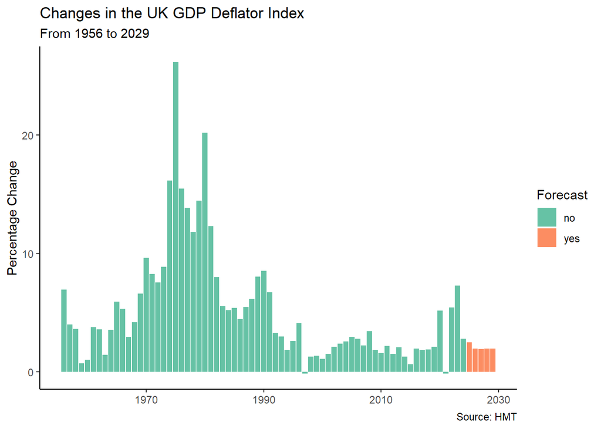

```r
gdp_deflators_df |>
  ggplot(aes(x = year, y = pct_change, fill = if_else(year > 2024, "yes", "no"))) +
  geom_col() +
  labs(
    title = "Changes in the UK GDP Deflator Index",
    subtitle = "From 1956 to 2029",
    x = NULL,
    y = "Percentage Change",
    fill = "Forecast",
    caption = "Source: HMT"
  ) +
  scale_fill_brewer(palette = "Set2") +
  theme_classic()
```

By using the Government Analysis Function theme as supplied by `{afcharts}` package, we get the following:

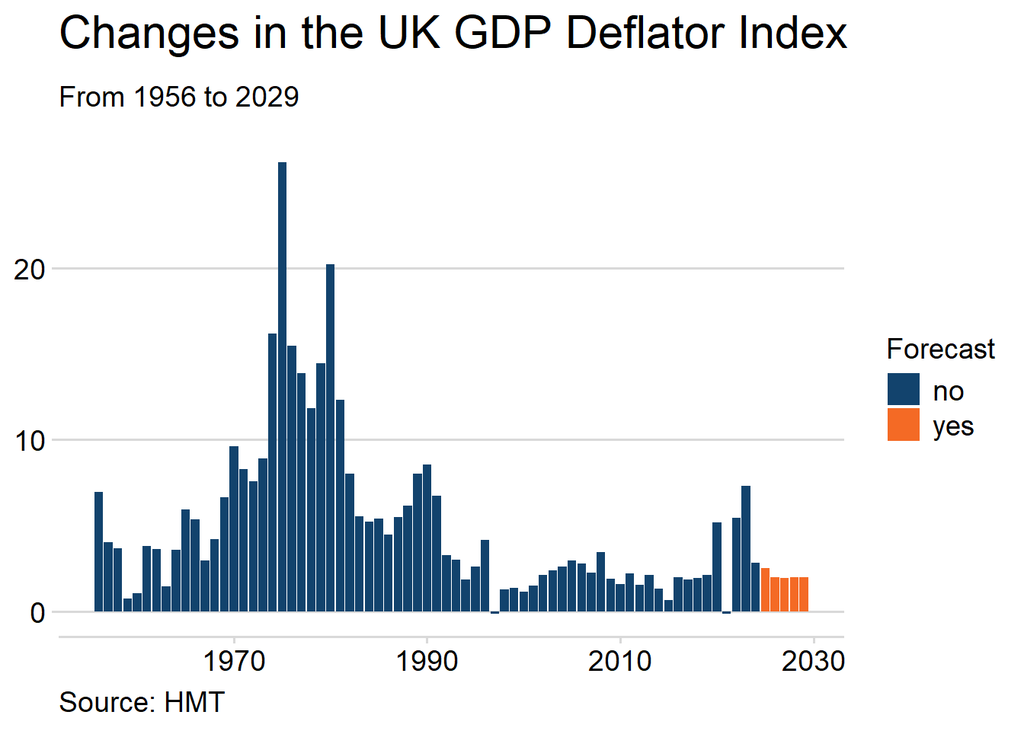

```r
gdp_deflators_df |>
  ggplot(aes(x = year, y = pct_change, fill = if_else(year > 2024, "yes", "no"))) +
  geom_col() +
  labs(
    title = "Changes in the UK GDP Deflator Index",
    subtitle = "From 1956 to 2029",
    x = NULL,
    y = NULL,
    fill = "Forecast",
    caption = "Source: HMT"
  ) +
  # applying AF colour theme
  scale_fill_discrete_af() +
  # apply the AF theme
  theme_af()
```

## Saving plots

Plots created can be saved as an image. This includes png, jpeg, svg and pdf formats. The format is determined by file extension specified in the `filename` argument.

```r
ggsave(filename = "images/gdp-deflators.png")
```

By default, the last plot created is saved.

In addition, the height, width, image quality can call be specified when saving.

We will save a pdf of the image, with a width of 20cm, height of 12cm and a dip (dots per inch) of 400.

```r
ggsave(
  filename = "images/gdp-deflators.pdf",
  width = 20,
  height = 12,
  units = "cm",
  dpi = 400
  )
```